# Ex_Regularized_Regression

Ghadi K

08-11-2020

Using the Hitters dataset from the ISLR package I solve the following questions:

```r
# import dataset
data(Hitters, package = "ISLR")
head(Hitters)
```

```
##                   AtBat Hits HmRun Runs RBI Walks Years CAtBat CHits CHmRun
## -Andy Allanson      293   66     1   30  29    14     1    293    66      1
## -Alan Ashby         315   81     7   24  38    39    14   3449   835     69
## -Alvin Davis        479  130    18   66  72    76     3   1624   457     63
## -Andre Dawson       496  141    20   65  78    37    11   5628  1575    225
## -Andres Galarraga   321   87    10   39  42    30     2    396   101     12
## -Alfredo Griffin    594  169     4   74  51    35    11   4408  1133     19
##                   CRuns CRBI CWalks League Division PutOuts Assists Errors
## -Andy Allanson       30   29     14      A        E     446      33     20
## -Alan Ashby         321  414    375      N        W     632      43     10
## -Alvin Davis        224  266    263      A        W     880      82     14
## -Andre Dawson       828  838    354      N        E     200      11      3
## -Andres Galarraga    48   46     33      N        E     805      40      4
## -Alfredo Griffin    501  336    194      A        W     282     421     25
##                   Salary NewLeague
## -Andy Allanson        NA         A
## -Alan Ashby        475.0         N
## -Alvin Davis       480.0         A
## -Andre Dawson      500.0         N
## -Andres Galarraga   91.5         N
## -Alfredo Griffin   750.0         A
```

```r
Hitters <- drop_na(Hitters)
# split data
set.seed(123)
split <- initial_split(Hitters, strata = "Salary")
Hitters_train <- training(split)
```

#Question 1 Apply a ridge model with glmnet with Salary being the response variable. What is the minimum MSE? What is the minimum MSE within 1 standard error? What are the lambda values for these MSEs?

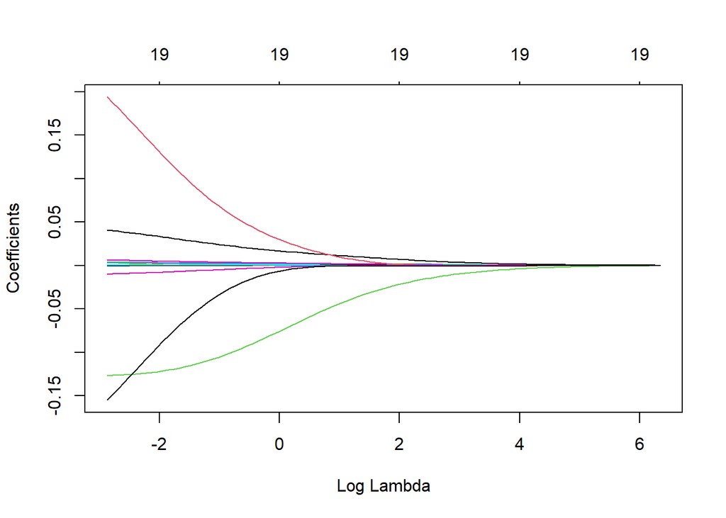

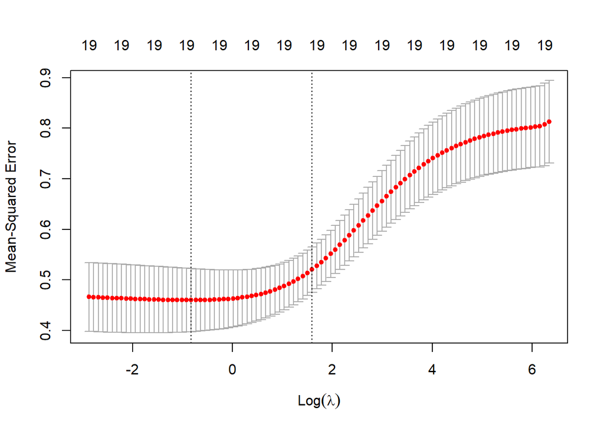

```
## [1] 0.4598649
```

```
## [1] 0.4384605
```

```
## [1] 0.5202639
```

```
## s51
##  19
```

#Question 2 Apply a lasso model with glmnet. What is the minimum MSE? What is the minimum MSE within 1 standard error? What are the lambda values for these MSEs?

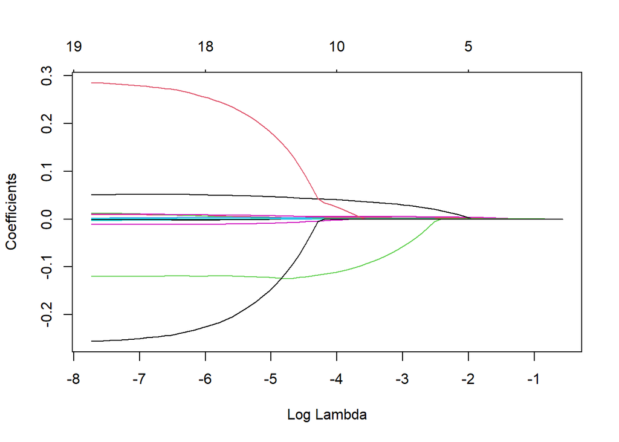

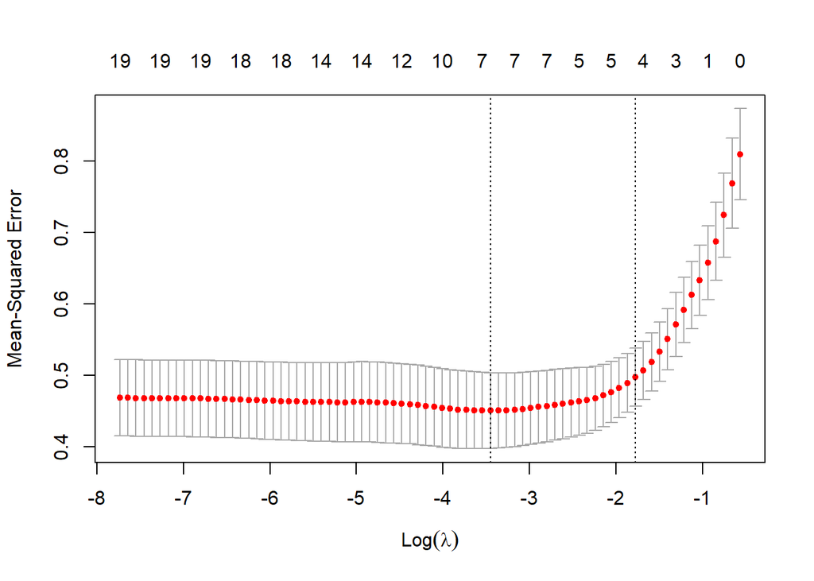

```
## [1] 0.450248
```

```
## [1] 0.03166039
```

```
## [1] 0.4967935
```

```
## s13
##   4
```

#Question 3 Perform a grid search across alpha parameter values ranging between 0–1. What is the optimal alpha and lambda values? What is the MSE and RMSE for this optimal model? How does it compare to your previous models?

```
##   alpha     lambda      RMSE  Rsquared      MAE    RMSESD RsquaredSD      MAESD
## 1     1 0.03976729 0.6593743 0.5327206 0.541722 0.1146273  0.1914451 0.07387789
```

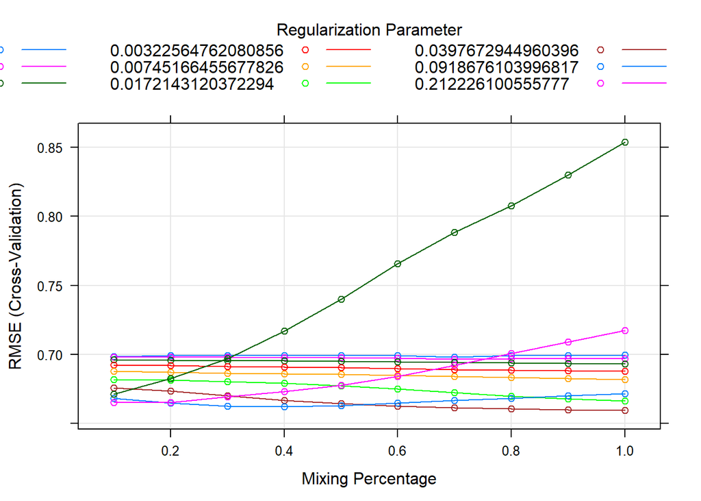

```
## [1] 388.9987
```

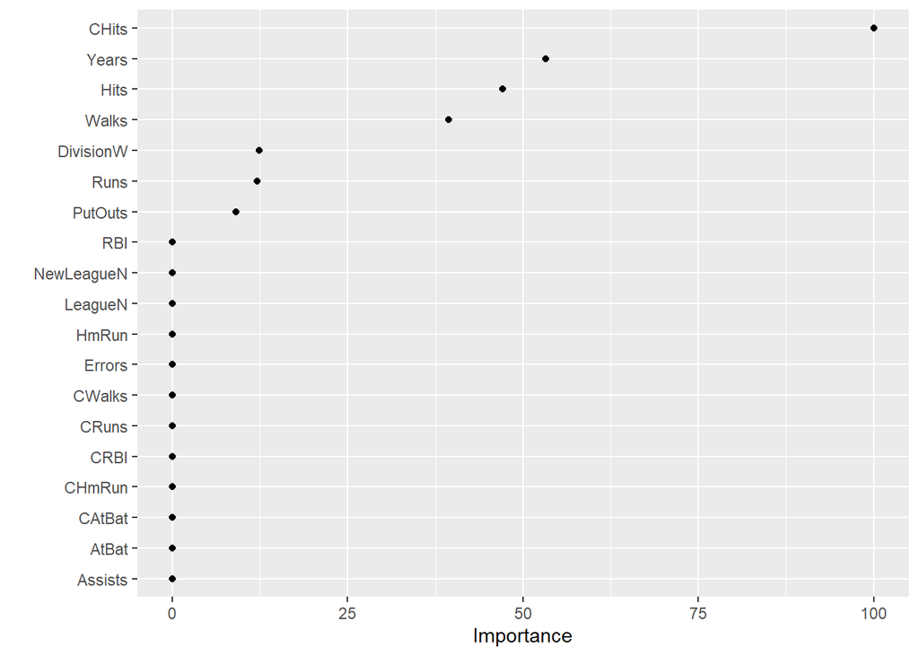